# SQ 016

## Your answer:

     - $z_1 =$

#### Solution

#### Question

132. Let $z_1$ be a [complex number](https://en.wikipedia.org/wiki/Complex_number#Polar_complex_plane) with modulus $r=10.817$ and argument $\theta=-2.159$ radians. **Express $z_1$ in rectangular form ($a+bi$).**

     The following formulas will be useful:
     $$a = r\cos(\theta)$$
     $$b = r\sin(\theta)$$

     To visualize, $z_1$ is graphed on a [complex plane](https://en.wikipedia.org/wiki/Complex_plane) below.

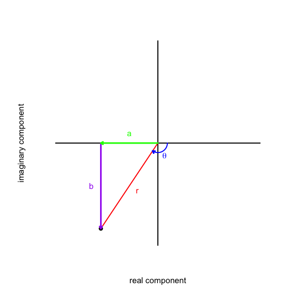

     Please round the components to the nearest integer.

## Your answer:

     - $z_1 =$

#### Solution

#### Question

133. Let $z_1$ be a [complex number](https://en.wikipedia.org/wiki/Complex_number#Polar_complex_plane) with modulus $r=12.042$ and argument $\theta=0.844$ radians. **Express $z_1$ in rectangular form ($a+bi$).**

     The following formulas will be useful:
     $$a = r\cos(\theta)$$
     $$b = r\sin(\theta)$$

     To visualize, $z_1$ is graphed on a [complex plane](https://en.wikipedia.org/wiki/Complex_plane) below.

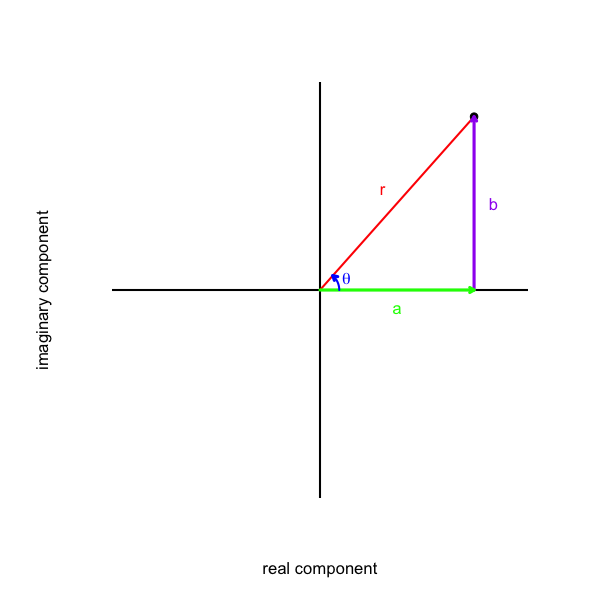

     Please round the components to the nearest integer.

## Your answer:

     - $z_1 =$

#### Solution

#### Question

134. Let $z_1$ be a [complex number](https://en.wikipedia.org/wiki/Complex_number#Polar_complex_plane) with modulus $r=9.899$ and argument $\theta=2.356$ radians. **Express $z_1$ in rectangular form ($a+bi$).**

     The following formulas will be useful:
     $$a = r\cos(\theta)$$
     $$b = r\sin(\theta)$$

     To visualize, $z_1$ is graphed on a [complex plane](https://en.wikipedia.org/wiki/Complex_plane) below.

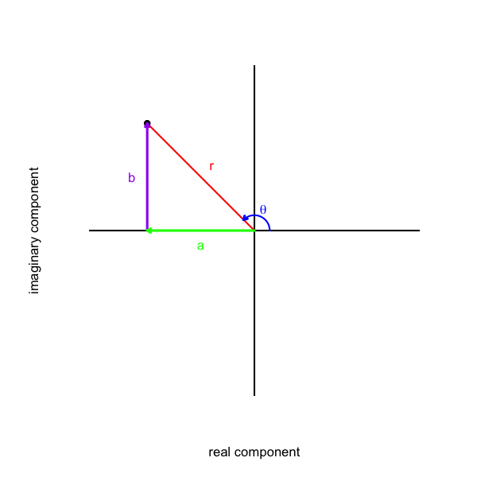

     Please round the components to the nearest integer.

## Your answer:

     - $z_1 =$

#### Solution

#### Question

135. Let $z_1$ be a [complex number](https://en.wikipedia.org/wiki/Complex_number#Polar_complex_plane) with modulus $r=9.487$ and argument $\theta=-1.893$ radians. **Express $z_1$ in rectangular form ($a+bi$).**

     The following formulas will be useful:
     $$a = r\cos(\theta)$$
     $$b = r\sin(\theta)$$

     To visualize, $z_1$ is graphed on a [complex plane](https://en.wikipedia.org/wiki/Complex_plane) below.

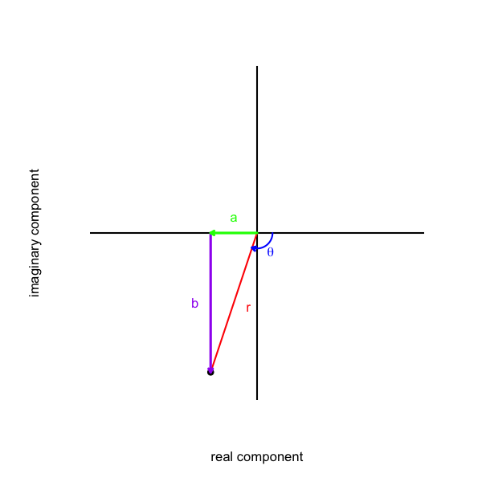

     Please round the components to the nearest integer.

## Your answer:

     - $z_1 =$

#### Solution

#### Question

136. Let $z_1$ be a [complex number](https://en.wikipedia.org/wiki/Complex_number#Polar_complex_plane) with modulus $r=7.616$ and argument $\theta=2.737$ radians. **Express $z_1$ in rectangular form ($a+bi$).**

     The following formulas will be useful:
     $$a = r\cos(\theta)$$
     $$b = r\sin(\theta)$$

     To visualize, $z_1$ is graphed on a [complex plane](https://en.wikipedia.org/wiki/Complex_plane) below.

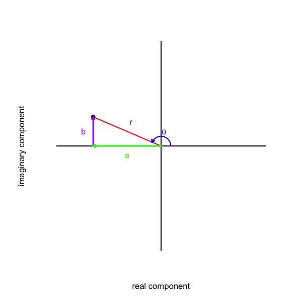

     Please round the components to the nearest integer.

## Your answer:

     - $z_1 =$

#### Solution

#### Question

137. Let $z_1$ be a [complex number](https://en.wikipedia.org/wiki/Complex_number#Polar_complex_plane) with modulus $r=9.487$ and argument $\theta=-1.249$ radians. **Express $z_1$ in rectangular form ($a+bi$).**

     The following formulas will be useful:
     $$a = r\cos(\theta)$$
     $$b = r\sin(\theta)$$

     To visualize, $z_1$ is graphed on a [complex plane](https://en.wikipedia.org/wiki/Complex_plane) below.

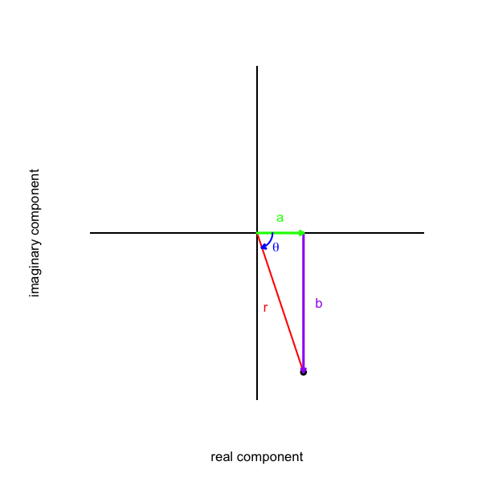

     Please round the components to the nearest integer.

## Your answer:

     - $z_1 =$

#### Solution

#### Question

138. Let $z_1$ be a [complex number](https://en.wikipedia.org/wiki/Complex_number#Polar_complex_plane) with modulus $r=9.434$ and argument $\theta=-2.129$ radians. **Express $z_1$ in rectangular form ($a+bi$).**

     The following formulas will be useful:
     $$a = r\cos(\theta)$$
     $$b = r\sin(\theta)$$

     To visualize, $z_1$ is graphed on a [complex plane](https://en.wikipedia.org/wiki/Complex_plane) below.

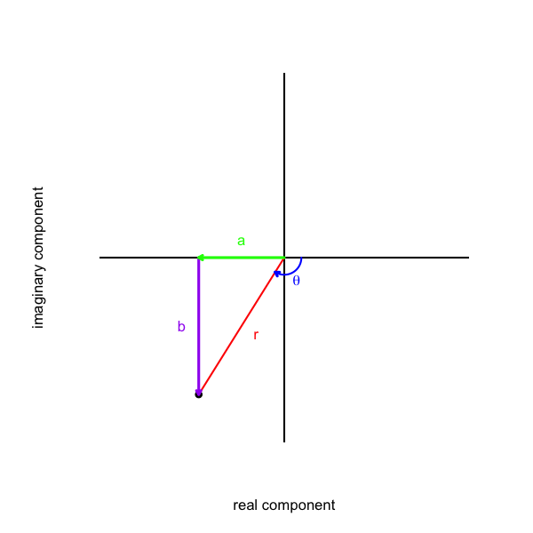

     Please round the components to the nearest integer.

## Your answer:

     - $z_1 =$

#### Solution

#### Question

139. Let $z_1$ be a [complex number](https://en.wikipedia.org/wiki/Complex_number#Polar_complex_plane) with modulus $r=5.831$ and argument $\theta=-2.601$ radians. **Express $z_1$ in rectangular form ($a+bi$).**

     The following formulas will be useful:
     $$a = r\cos(\theta)$$
     $$b = r\sin(\theta)$$

     To visualize, $z_1$ is graphed on a [complex plane](https://en.wikipedia.org/wiki/Complex_plane) below.

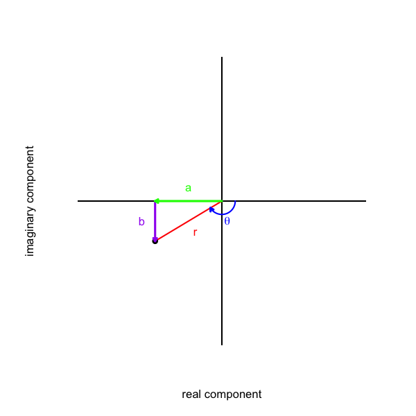

     Please round the components to the nearest integer.

## Your answer:

     - $z_1 =$

#### Solution

#### Question

140. Let $z_1$ be a [complex number](https://en.wikipedia.org/wiki/Complex_number#Polar_complex_plane) with modulus $r=6.403$ and argument $\theta=-2.246$ radians. **Express $z_1$ in rectangular form ($a+bi$).**

     The following formulas will be useful:
     $$a = r\cos(\theta)$$
     $$b = r\sin(\theta)$$

     To visualize, $z_1$ is graphed on a [complex plane](https://en.wikipedia.org/wiki/Complex_plane) below.

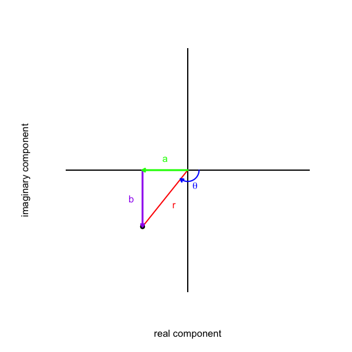

     Please round the components to the nearest integer.

## Your answer:

     - $z_1 =$

#### Solution

#### Question

### Background

141. [Multiplying complex numbers from their polar parameters](https://en.wikipedia.org/wiki/Complex_number#Multiplication_and_division_in_polar_form) is surprisingly easy. Let $z_1$ have modulus $r_1$ and argument $\theta_1$. And let $z_2$ have modulus $r_2$ and argument $\theta_2$.
     $$z_1 ~~=~~ r_1\cos(\theta_1)~+~r_1\sin(\theta_1)i$$
     $$z_2 ~~=~~ r_2\cos(\theta_2)~+~r_2\sin(\theta_2)i$$
     Let a third complex number $z_3$ have modulus $r_3$ and argument $\theta_3$ and equal the product of the other two numbers.
     $$z_3 = z_1 \cdot z_2$$
     It can be proven that the product’s modulus is the **product** of the moduli, and the product’s argument is the **sum** of the arguments.
     $$r_3 = r_1 \cdot r_2$$
     $$\theta_3 = \theta_1 + \theta_2$$

### The Question

     Complex number $z_1$ has modulus $r_1=1.7$ and argument $\theta_1=-1.3$ radians. Complex number $z_2$ has modulus $r_2=2.3$ and argument $\theta_2=-0.8$ radians. Complex number $z_3$ is the product of $z_1$ and $z_2$. Find the polar parameters of $z_3$.
     - $r_3=$
     - $\theta_3=$

#### Solution

#### Question

### Background

142. [Multiplying complex numbers from their polar parameters](https://en.wikipedia.org/wiki/Complex_number#Multiplication_and_division_in_polar_form) is surprisingly easy. Let $z_1$ have modulus $r_1$ and argument $\theta_1$. And let $z_2$ have modulus $r_2$ and argument $\theta_2$.
     $$z_1 ~~=~~ r_1\cos(\theta_1)~+~r_1\sin(\theta_1)i$$
     $$z_2 ~~=~~ r_2\cos(\theta_2)~+~r_2\sin(\theta_2)i$$
     Let a third complex number $z_3$ have modulus $r_3$ and argument $\theta_3$ and equal the product of the other two numbers.
     $$z_3 = z_1 \cdot z_2$$
     It can be proven that the product’s modulus is the **product** of the moduli, and the product’s argument is the **sum** of the arguments.
     $$r_3 = r_1 \cdot r_2$$
     $$\theta_3 = \theta_1 + \theta_2$$

### The Question

     Complex number $z_1$ has modulus $r_1=2.2$ and argument $\theta_1=0.8$ radians. Complex number $z_2$ has modulus $r_2=1.3$ and argument $\theta_2=-0.8$ radians. Complex number $z_3$ is the product of $z_1$ and $z_2$. Find the polar parameters of $z_3$.
     - $r_3=$
     - $\theta_3=$

#### Solution

#### Question

### Background

143. [Multiplying complex numbers from their polar parameters](https://en.wikipedia.org/wiki/Complex_number#Multiplication_and_division_in_polar_form) is surprisingly easy. Let $z_1$ have modulus $r_1$ and argument $\theta_1$. And let $z_2$ have modulus $r_2$ and argument $\theta_2$.
     $$z_1 ~~=~~ r_1\cos(\theta_1)~+~r_1\sin(\theta_1)i$$
     $$z_2 ~~=~~ r_2\cos(\theta_2)~+~r_2\sin(\theta_2)i$$
     Let a third complex number $z_3$ have modulus $r_3$ and argument $\theta_3$ and equal the product of the other two numbers.
     $$z_3 = z_1 \cdot z_2$$
     It can be proven that the product’s modulus is the **product** of the moduli, and the product’s argument is the **sum** of the arguments.
     $$r_3 = r_1 \cdot r_2$$
     $$\theta_3 = \theta_1 + \theta_2$$

### The Question

     Complex number $z_1$ has modulus $r_1=1.8$ and argument $\theta_1=-1.5$ radians. Complex number $z_2$ has modulus $r_2=2.2$ and argument $\theta_2=-0.2$ radians. Complex number $z_3$ is the product of $z_1$ and $z_2$. Find the polar parameters of $z_3$.
     - $r_3=$
     - $\theta_3=$

#### Solution

#### Question

### Background

144. [Multiplying complex numbers from their polar parameters](https://en.wikipedia.org/wiki/Complex_number#Multiplication_and_division_in_polar_form) is surprisingly easy. Let $z_1$ have modulus $r_1$ and argument $\theta_1$. And let $z_2$ have modulus $r_2$ and argument $\theta_2$.
     $$z_1 ~~=~~ r_1\cos(\theta_1)~+~r_1\sin(\theta_1)i$$
     $$z_2 ~~=~~ r_2\cos(\theta_2)~+~r_2\sin(\theta_2)i$$
     Let a third complex number $z_3$ have modulus $r_3$ and argument $\theta_3$ and equal the product of the other two numbers.
     $$z_3 = z_1 \cdot z_2$$
     It can be proven that the product’s modulus is the **product** of the moduli, and the product’s argument is the **sum** of the arguments.
     $$r_3 = r_1 \cdot r_2$$
     $$\theta_3 = \theta_1 + \theta_2$$

### The Question

     Complex number $z_1$ has modulus $r_1=2.1$ and argument $\theta_1=-0.8$ radians. Complex number $z_2$ has modulus $r_2=1.4$ and argument $\theta_2=-1.1$ radians. Complex number $z_3$ is the product of $z_1$ and $z_2$. Find the polar parameters of $z_3$.
     - $r_3=$
     - $\theta_3=$

#### Solution

#### Question

### Background

145. [Multiplying complex numbers from their polar parameters](https://en.wikipedia.org/wiki/Complex_number#Multiplication_and_division_in_polar_form) is surprisingly easy. Let $z_1$ have modulus $r_1$ and argument $\theta_1$. And let $z_2$ have modulus $r_2$ and argument $\theta_2$.
     $$z_1 ~~=~~ r_1\cos(\theta_1)~+~r_1\sin(\theta_1)i$$
     $$z_2 ~~=~~ r_2\cos(\theta_2)~+~r_2\sin(\theta_2)i$$
     Let a third complex number $z_3$ have modulus $r_3$ and argument $\theta_3$ and equal the product of the other two numbers.
     $$z_3 = z_1 \cdot z_2$$
     It can be proven that the product’s modulus is the **product** of the moduli, and the product’s argument is the **sum** of the arguments.
     $$r_3 = r_1 \cdot r_2$$
     $$\theta_3 = \theta_1 + \theta_2$$

### The Question

     Complex number $z_1$ has modulus $r_1=1$ and argument $\theta_1=1$ radians. Complex number $z_2$ has modulus $r_2=1.3$ and argument $\theta_2=1.5$ radians. Complex number $z_3$ is the product of $z_1$ and $z_2$. Find the polar parameters of $z_3$.
     - $r_3=$
     - $\theta_3=$

#### Solution

#### Question

### Background

146. [Multiplying complex numbers from their polar parameters](https://en.wikipedia.org/wiki/Complex_number#Multiplication_and_division_in_polar_form) is surprisingly easy. Let $z_1$ have modulus $r_1$ and argument $\theta_1$. And let $z_2$ have modulus $r_2$ and argument $\theta_2$.
     $$z_1 ~~=~~ r_1\cos(\theta_1)~+~r_1\sin(\theta_1)i$$
     $$z_2 ~~=~~ r_2\cos(\theta_2)~+~r_2\sin(\theta_2)i$$
     Let a third complex number $z_3$ have modulus $r_3$ and argument $\theta_3$ and equal the product of the other two numbers.
     $$z_3 = z_1 \cdot z_2$$
     It can be proven that the product’s modulus is the **product** of the moduli, and the product’s argument is the **sum** of the arguments.
     $$r_3 = r_1 \cdot r_2$$
     $$\theta_3 = \theta_1 + \theta_2$$

### The Question

     Complex number $z_1$ has modulus $r_1=3$ and argument $\theta_1=0.1$ radians. Complex number $z_2$ has modulus $r_2=2.4$ and argument $\theta_2=0.3$ radians. Complex number $z_3$ is the product of $z_1$ and $z_2$. Find the polar parameters of $z_3$.
     - $r_3=$
     - $\theta_3=$

#### Solution

#### Question

### Background

147. [Multiplying complex numbers from their polar parameters](https://en.wikipedia.org/wiki/Complex_number#Multiplication_and_division_in_polar_form) is surprisingly easy. Let $z_1$ have modulus $r_1$ and argument $\theta_1$. And let $z_2$ have modulus $r_2$ and argument $\theta_2$.
     $$z_1 ~~=~~ r_1\cos(\theta_1)~+~r_1\sin(\theta_1)i$$
     $$z_2 ~~=~~ r_2\cos(\theta_2)~+~r_2\sin(\theta_2)i$$
     Let a third complex number $z_3$ have modulus $r_3$ and argument $\theta_3$ and equal the product of the other two numbers.
     $$z_3 = z_1 \cdot z_2$$
     It can be proven that the product’s modulus is the **product** of the moduli, and the product’s argument is the **sum** of the arguments.
     $$r_3 = r_1 \cdot r_2$$
     $$\theta_3 = \theta_1 + \theta_2$$

### The Question

     Complex number $z_1$ has modulus $r_1=2.2$ and argument $\theta_1=0.6$ radians. Complex number $z_2$ has modulus $r_2=1.6$ and argument $\theta_2=-0.4$ radians. Complex number $z_3$ is the product of $z_1$ and $z_2$. Find the polar parameters of $z_3$.
     - $r_3=$
     - $\theta_3=$

#### Solution

#### Question

### Background

148. [Multiplying complex numbers from their polar parameters](https://en.wikipedia.org/wiki/Complex_number#Multiplication_and_division_in_polar_form) is surprisingly easy. Let $z_1$ have modulus $r_1$ and argument $\theta_1$. And let $z_2$ have modulus $r_2$ and argument $\theta_2$.
     $$z_1 ~~=~~ r_1\cos(\theta_1)~+~r_1\sin(\theta_1)i$$
     $$z_2 ~~=~~ r_2\cos(\theta_2)~+~r_2\sin(\theta_2)i$$
     Let a third complex number $z_3$ have modulus $r_3$ and argument $\theta_3$ and equal the product of the other two numbers.
     $$z_3 = z_1 \cdot z_2$$
     It can be proven that the product’s modulus is the **product** of the moduli, and the product’s argument is the **sum** of the arguments.
     $$r_3 = r_1 \cdot r_2$$
     $$\theta_3 = \theta_1 + \theta_2$$

### The Question

     Complex number $z_1$ has modulus $r_1=1.8$ and argument $\theta_1=-0.9$ radians. Complex number $z_2$ has modulus $r_2=1.9$ and argument $\theta_2=-0.5$ radians. Complex number $z_3$ is the product of $z_1$ and $z_2$. Find the polar parameters of $z_3$.
     - $r_3=$
     - $\theta_3=$

#### Solution

#### Question

### Background

149. [Multiplying complex numbers from their polar parameters](https://en.wikipedia.org/wiki/Complex_number#Multiplication_and_division_in_polar_form) is surprisingly easy. Let $z_1$ have modulus $r_1$ and argument $\theta_1$. And let $z_2$ have modulus $r_2$ and argument $\theta_2$.
     $$z_1 ~~=~~ r_1\cos(\theta_1)~+~r_1\sin(\theta_1)i$$
     $$z_2 ~~=~~ r_2\cos(\theta_2)~+~r_2\sin(\theta_2)i$$
     Let a third complex number $z_3$ have modulus $r_3$ and argument $\theta_3$ and equal the product of the other two numbers.
     $$z_3 = z_1 \cdot z_2$$
     It can be proven that the product’s modulus is the **product** of the moduli, and the product’s argument is the **sum** of the arguments.
     $$r_3 = r_1 \cdot r_2$$
     $$\theta_3 = \theta_1 + \theta_2$$

### The Question

     Complex number $z_1$ has modulus $r_1=2.1$ and argument $\theta_1=1.5$ radians. Complex number $z_2$ has modulus $r_2=1.3$ and argument $\theta_2=-0.8$ radians. Complex number $z_3$ is the product of $z_1$ and $z_2$. Find the polar parameters of $z_3$.
     - $r_3=$
     - $\theta_3=$

#### Solution

#### Question

### Background

150. [Multiplying complex numbers from their polar parameters](https://en.wikipedia.org/wiki/Complex_number#Multiplication_and_division_in_polar_form) is surprisingly easy. Let $z_1$ have modulus $r_1$ and argument $\theta_1$. And let $z_2$ have modulus $r_2$ and argument $\theta_2$.
     $$z_1 ~~=~~ r_1\cos(\theta_1)~+~r_1\sin(\theta_1)i$$
     $$z_2 ~~=~~ r_2\cos(\theta_2)~+~r_2\sin(\theta_2)i$$
     Let a third complex number $z_3$ have modulus $r_3$ and argument $\theta_3$ and equal the product of the other two numbers.
     $$z_3 = z_1 \cdot z_2$$
     It can be proven that the product’s modulus is the **product** of the moduli, and the product’s argument is the **sum** of the arguments.
     $$r_3 = r_1 \cdot r_2$$
     $$\theta_3 = \theta_1 + \theta_2$$

### The Question

     Complex number $z_1$ has modulus $r_1=1.8$ and argument $\theta_1=0.6$ radians. Complex number $z_2$ has modulus $r_2=1.1$ and argument $\theta_2=1.5$ radians. Complex number $z_3$ is the product of $z_1$ and $z_2$. Find the polar parameters of $z_3$.
     - $r_3=$
     - $\theta_3=$

#### Solution

#### Question

151. Find solutions to the polynomial equation below.
     $$z^{6} - 6 z^{5} + 25 z^{4} - 81 z^{2} + 486 z - 2025=0$$

     To find the solutions, I’d recommend using [this website](https://samuelj.li/complex-function-plotter/#z%5E6-6*z%5E5%2B25*z%5E4-81*z%5E2%2B486*z-2025), which uses [domain coloring](https://en.wikipedia.org/wiki/Domain_coloring) to visualize the solutions. By default the solutions will appear as the center of concentric rings.
     1. -1-4i
     2. -1+4i
     3. -3
     4. -3i
     5. -4-4i
     6. -4+4i
     7. 3
     8. 3-4i
     9. 3+4i
     10. 3i

#### Solution

#### Question

152. Find solutions to the polynomial equation below.
     $$z^{6} + 9 z^{5} + 25 z^{4} + 15 z^{3} + 424 z^{2} + 1326 z=0$$

     To find the solutions, I’d recommend using [this website](https://samuelj.li/complex-function-plotter/#z%5E6%2B9*z%5E5%2B25*z%5E4%2B15*z%5E3%2B424*z%5E2%2B1326*z), which uses [domain coloring](https://en.wikipedia.org/wiki/Domain_coloring) to visualize the solutions. By default the solutions will appear as the center of concentric rings.
     1. -3
     2. -4
     3. -5-3i
     4. -5+3i
     5. 0
     6. 2-3i
     7. 2+3i
     8. 4
     9. 5-3i
     10. 5+3i

#### Solution

#### Question

153. Find solutions to the polynomial equation below.
     $$z^{5} - 12 z^{4} + 52 z^{3} - 92 z^{2} + 51 z=0$$

     To find the solutions, I’d recommend using [this website](https://samuelj.li/complex-function-plotter/#z%5E5-12*z%5E4%2B52*z%5E3-92*z%5E2%2B51*z), which uses [domain coloring](https://en.wikipedia.org/wiki/Domain_coloring) to visualize the solutions. By default the solutions will appear as the center of concentric rings.
     1. -2-i
     2. -2+i
     3. -4
     4. -5
     5. 0
     6. 1
     7. 2
     8. 3
     9. 4-i
     10. 4+i

#### Solution

#### Question

154. Find solutions to the polynomial equation below.
     $$z^{5} + 6 z^{4} - 8 z^{3} - 146 z^{2} - 393 z - 260=0$$

     To find the solutions, I’d recommend using [this website](https://samuelj.li/complex-function-plotter/#z%5E5%2B6*z%5E4-8*z%5E3-146*z%5E2-393*z-260), which uses [domain coloring](https://en.wikipedia.org/wiki/Domain_coloring) to visualize the solutions. By default the solutions will appear as the center of concentric rings.
     1. -1
     2. -3-2i
     3. -3+2i
     4. -4
     5. -4i
     6. 2-5i
     7. 2+5i
     8. 4
     9. 4i
     10. 5

#### Solution

#### Question

155. Find solutions to the polynomial equation below.
     $$z^{6} - 3 z^{5} + 142 z^{3} + 8 z^{2} + 512 z + 3840=0$$

     To find the solutions, I’d recommend using [this website](https://samuelj.li/complex-function-plotter/#z%5E6-3*z%5E5%2B142*z%5E3%2B8*z%5E2%2B512*z%2B3840), which uses [domain coloring](https://en.wikipedia.org/wiki/Domain_coloring) to visualize the solutions. By default the solutions will appear as the center of concentric rings.
     1. -1
     2. -3
     3. -4
     4. -5-i
     5. -5+i
     6. 1-3i
     7. 1+3i
     8. 2
     9. 4-4i
     10. 4+4i

#### Solution

#### Question

156. Find solutions to the polynomial equation below.
     $$z^{6} + 17 z^{5} + 129 z^{4} + 577 z^{3} + 1600 z^{2} + 2616 z + 2080=0$$

     To find the solutions, I’d recommend using [this website](https://samuelj.li/complex-function-plotter/#z%5E6%2B17*z%5E5%2B129*z%5E4%2B577*z%5E3%2B1600*z%5E2%2B2616*z%2B2080), which uses [domain coloring](https://en.wikipedia.org/wiki/Domain_coloring) to visualize the solutions. By default the solutions will appear as the center of concentric rings.
     1. -2-2i
     2. -2-3i
     3. -2+2i
     4. -2+3i
     5. -4
     6. -5
     7. -5-3i
     8. -5+3i
     9. 2
     10. 4

#### Solution

#### Question

157. Find solutions to the polynomial equation below.
     $$z^{4} + 8 z^{3} + 22 z^{2} + 20 z=0$$

     To find the solutions, I’d recommend using [this website](https://samuelj.li/complex-function-plotter/#z%5E4%2B8*z%5E3%2B22*z%5E2%2B20*z), which uses [domain coloring](https://en.wikipedia.org/wiki/Domain_coloring) to visualize the solutions. By default the solutions will appear as the center of concentric rings.
     1. -1
     2. -2
     3. -3
     4. -3-i
     5. -3+i
     6. 0
     7. 4
     8. 4-i
     9. 4+i
     10. 5

#### Solution

#### Question

158. Find solutions to the polynomial equation below.
     $$z^{6} - 8 z^{5} + 18 z^{4} - 30 z^{3} + 103 z^{2} - 170 z + 150=0$$

     To find the solutions, I’d recommend using [this website](https://samuelj.li/complex-function-plotter/#z%5E6-8*z%5E5%2B18*z%5E4-30*z%5E3%2B103*z%5E2-170*z%2B150), which uses [domain coloring](https://en.wikipedia.org/wiki/Domain_coloring) to visualize the solutions. By default the solutions will appear as the center of concentric rings.
     1. -1-2i
     2. -1+2i
     3. -4-2i
     4. -4+2i
     5. 1-i
     6. 1+i
     7. 2-4i
     8. 2+4i
     9. 3
     10. 5

#### Solution

#### Question

159. Find solutions to the polynomial equation below.
     $$z^{6} - 10 z^{5} + 340 z^{3} - 931 z^{2} - 2250 z + 7650=0$$

     To find the solutions, I’d recommend using [this website](https://samuelj.li/complex-function-plotter/#z%5E6-10*z%5E5%2B340*z%5E3-931*z%5E2-2250*z%2B7650), which uses [domain coloring](https://en.wikipedia.org/wiki/Domain_coloring) to visualize the solutions. By default the solutions will appear as the center of concentric rings.
     1. -2
     2. -3
     3. -5
     4. 0
     5. 3
     6. 3-3i
     7. 3+3i
     8. 5
     9. 5-3i
     10. 5+3i

#### Solution

#### Question

160. Find solutions to the polynomial equation below.
     $$z^{6} - 2 z^{5} - 28 z^{4} - 36 z^{3} + 619 z^{2} - 370 z - 1000=0$$

     To find the solutions, I’d recommend using [this website](https://samuelj.li/complex-function-plotter/#z%5E6-2*z%5E5-28*z%5E4-36*z%5E3%2B619*z%5E2-370*z-1000), which uses [domain coloring](https://en.wikipedia.org/wiki/Domain_coloring) to visualize the solutions. By default the solutions will appear as the center of concentric rings.
     1. -1
     2. -3
     3. -4
     4. -4-3i
     5. -4+3i
     6. 2
     7. 2-5i
     8. 2+5i
     9. 4
     10. 5

#### Solution